# Milestone report

Exploratory data analysis: Relationships between words

agrou

14 April 2017

# Scope

Understand the distribution and relationship between the words, tokens and phares in the text and build a linguistic predictive model.

# Tasks

1. Exploratory Analysis
2. Understand frequencies of words and words pairs

# Questions

1. Some words are more frequent than others - what are the distributions of word frequencies?
2. What are the frequencies of 2-grams and 3-grams in the dataset?
3. How many unique words do you need in a frequency sorted dictionary to cover 50% of all word instances in the language? 90%?
4. How do you evaluate how many of the words come from foreign languages?
5. Can you think of a way to increase the coverage - identifying words that may not be in the corpora or using a smaller number of words in the dictionary to cover the same number of phrases?

# References

For this report I used Julia Silge’s Documentation for Tidy Text Mining: http://juliasilge.com/blog/Life-Changing-Magic/ http://tidytextmining.com/ Feinerer, Hornik and Meyer. Text Mining Infrastructure in R. Journal of Statistical Software. 2008 (https://www.jstatsoft.org/article/view/v025i05)

# Data

Load the data

```r
# define the directory to store the zipfile
destfile <- "/Users/andreia/Documents/Data_Science_Projects/Coursera/courses/Capstone/Data/Coursera-Swiftkey.zip"
# save the URL with the zipfile
fileUrl <- "https://d396qusza40orc.cloudfront.net/dsscapstone/dataset/Coursera-SwiftKey.zip"
# Download the zipfile
download.file(url = fileUrl, destfile = destfile, method = "curl")
```

Load libraries

```r
library(purrr) # for map function
library(tidyverse)
library(tidytext)
library(stringr)
library(ggthemes)
library(gridExtra)
library(hunspell)
```

Read the data

```r
# Load the three data sets together

enUS_folder <- "Data/final/en_US/"

# create a function to read the three documents in the same file
read_folder <- function(infolder){
        tibble(file = dir(infolder, full.names = TRUE)) %>%
               mutate(text = map(file, read_lines)) %>%
               transmute(id = basename(file), text) %>%
               unnest(text)
}

files <- read_folder(enUS_folder)
head(files)
```

```
## # A tibble: 6 × 2
##                id
##             <chr>
## 1 en_US.blogs.txt
## 2 en_US.blogs.txt
## 3 en_US.blogs.txt
## 4 en_US.blogs.txt
## 5 en_US.blogs.txt
## 6 en_US.blogs.txt
## # ... with 1 more variables: text <chr>
```

The 3 files combined have 4597879 lines.

Resample data for quicker analysis

```r
# resample data
files3 <- files %>%
        sample_frac(0.2) #resample data
```

# Text mining and Natural language processing

## Data Cleaning and Tokenization

```r
cleanAll <- files3 %>%
        # rename the dataset/variable names
        mutate(id = str_replace_all(id, c("en_US.twitter.txt" = "Twitter",
                                             "en_US.news.txt" = "News",
                                             "en_US.blogs.txt" = "Blogs")),
               #replace all digits with nothing
               text = str_replace_all(text, "\\d+", ""),
               #replace bullet & html characters, single or double dashes and repeated vowels with a space
               text = str_replace_all(text, "[\r?\n|\røØ]|[^a-zA-Z0-9_']|\\_|\\b[aeiou]{2,}\\b", " "),
               #text = str_replace_all(text, "[^a-zA-Z0-9_']", " "), #replace non-english characters with space
               #text = str_replace_all(text, "\\_", " "), #replace all extra punctuation with nothing
               # replace words that are just repetitions of vowels with nothing
               #text = str_replace_all(text, "\\b[aeiou]{2,}\\b", " "),
               text = tolower(text)
               )
pander::pander(head(cleanAll))
```

| id | text |
| --- | --- |
| News | quality of service generally polite and efficient |
| Twitter | did my mom just say death carb for cutie or |
| Twitter | welcome to utopia we design and build furniture |
| Twitter | hrs min to see who’s the first if anyone who remembers |
| Twitter | of course did you scream |
| Blogs | thickened if too thick add milk until reaches desired consistency |

## Exploratory Analysis

### 1. Some words are more frequent than others - what are the distributions of word frequencies?

I start by transforming the text into single tokens (words).

```r
WordToken <- cleanAll %>%
        # Tokenization into words
        unnest_tokens(word, text) %>% # separate each line of text into word tokens
        filter(!str_detect(word, "\\b[aeiou]{2,}\\b")) %>% #remove words with only repeated vowels generated after tokenization
        anti_join(stop_words) #remove stopwords
```

`anti_join` function is used to remove *stopwords*.

What are the most common words in the whole corpus of text?

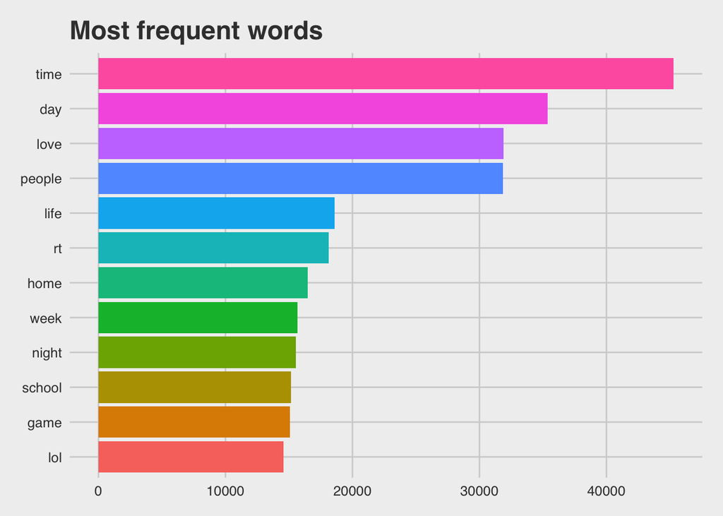

```r
AllCounts <- WordToken %>%
        count(word, sort = TRUE) %>%
        mutate(word = factor(word, levels = rev(unique(word)))) %>%
        top_n(12) %>%
        ggplot(aes(word, n, fill = word, order = n)) +
        geom_col(show.legend = FALSE) +
        ggtitle("Most frequent words") +
        xlab("Word counts") +
        coord_flip() +
        theme_fivethirtyeight()
AllCounts
```

The plot above represents the most frequent words in the whole text corpus.

But what are the group counts? The most frequent words by ID?

```r
IDCounts <- WordToken %>%
        group_by(id, word) %>%
        count(word, sort = TRUE)

head(IDCounts)
```

```
## Source: local data frame [6 x 3]
## Groups: id [2]
##
##        id  word     n
##     <chr> <chr> <int>
## 1 Twitter  love 21235
## 2 Twitter   day 18335
## 3   Blogs  time 18280
## 4 Twitter    rt 18100
## 5 Twitter  time 15477
## 6 Twitter   lol 13996
```

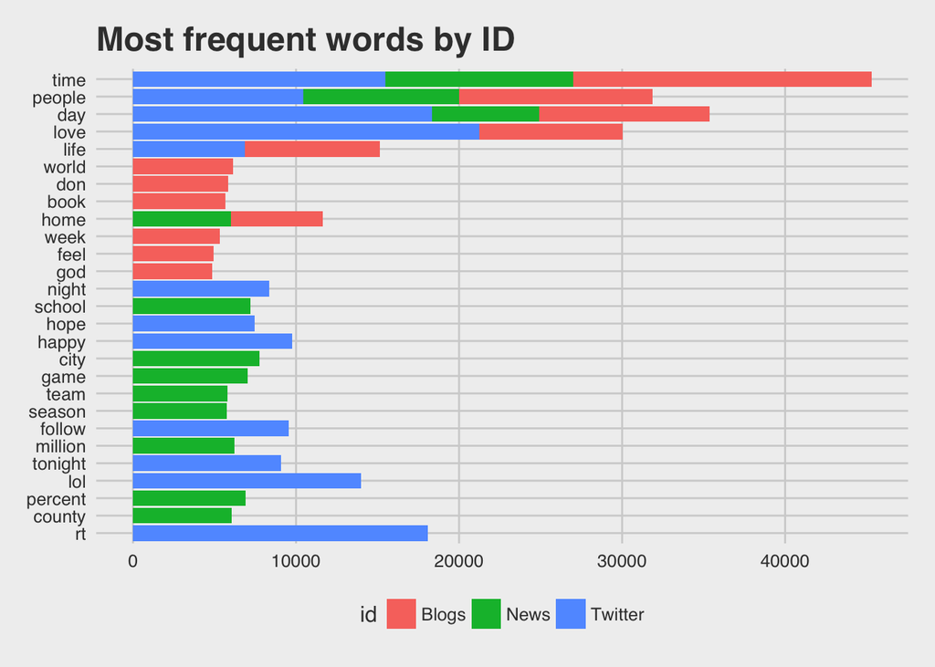

```r
WordFreq <- IDCounts %>%
        #convert words into factors for unique values
        mutate(word = factor(word, levels = rev(unique(word)))) %>%
        top_n(12) %>%
        ggplot(aes(word, n, fill = id, order = n)) +
        geom_col() +
        ggtitle("Most frequent words by ID") +
        xlab(NULL) +
        coord_flip() +
        theme_fivethirtyeight()
WordFreq
```

```r
# Total number of words by ID
TotalWords <- IDCounts %>%
        group_by(id) %>%
        summarise(total = sum(n))
pander::pander(TotalWords)
```

| id | total |
| --- | --- |
| Blogs | 2773941 |
| News | 3066575 |
| Twitter | 2395966 |

Here we see the three datasets have different lenghts, that’s one of the reasons why we should calculate the term frequencies (tf) along with the inverse document frequency (idf).

*idf* decreases the weight for commonly used words and increases the weight for words that are not used very much. *tf* and *idf* combined give the frequency of a term adjusted for how rarely it is used.

```r
tf <- IDCounts %>%
        bind_tf_idf(word, id, n) %>%
        arrange(desc(tf_idf))

head(tf)
```

```
## Source: local data frame [6 x 6]
## Groups: id [1]
##
##        id    word     n           tf       idf       tf_idf
##     <chr>   <chr> <int>        <dbl>     <dbl>        <dbl>
## 1 Twitter    shit  3492 0.0014574497 0.4054651 0.0005909450
## 2 Twitter    fuck  2513 0.0010488463 0.4054651 0.0004252706
## 3 Twitter    lmao  1664 0.0006945007 0.4054651 0.0002815958
## 4 Twitter fucking  1411 0.0005889065 0.4054651 0.0002387810
## 5 Twitter  hahaha  1313 0.0005480044 0.4054651 0.0002221967
## 6 Twitter     yea  1201 0.0005012592 0.4054651 0.0002032431
```

# Visualize top words within groups

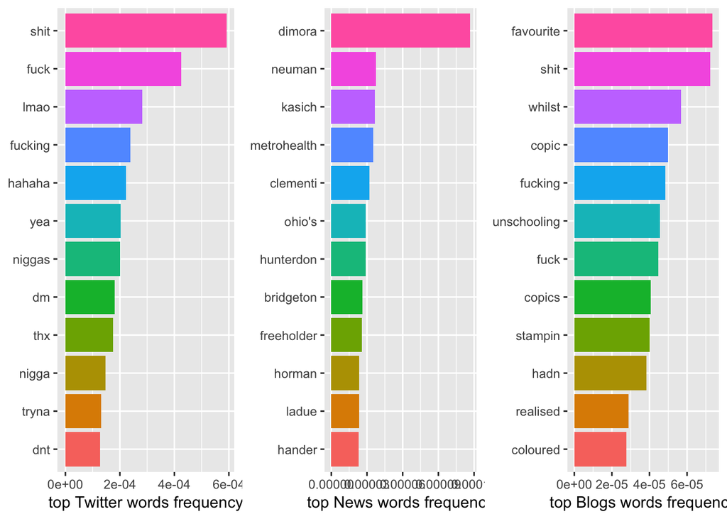

```r
Blogs_graph <- tf %>%
        filter(id == "Blogs") %>%
        # factoring is applied here to order the words by the top word frequencies
        mutate(word = factor(word, levels = rev(unique(word)))) %>%
        top_n(12) %>%
        ggplot(aes(word, tf_idf, fill = word)) +
        geom_col(show.legend = FALSE) +
        labs(x = NULL, y = "top Blogs words frequency") +
        coord_flip()
News_graph <- tf %>%
        filter(id == "News") %>%
        mutate(word = factor(word, levels = rev(unique(word)))) %>%
        top_n(12) %>%
        ggplot(aes(word, tf_idf, fill = word)) +
        geom_col(show.legend = FALSE) +
        labs(x = NULL, y = "top News words frequency") +
        coord_flip()
Twitter_graph <- tf %>%
        filter(id == "Twitter") %>%
        mutate(word = factor(word, levels = rev(unique(word)))) %>%
        top_n(12) %>%
        ggplot(aes(word, tf_idf, fill = word)) +
        geom_col(show.legend = FALSE) +
        labs(x = NULL, y = "top Twitter words frequency") +
        coord_flip()
grid.arrange(Twitter_graph, News_graph, Blogs_graph, ncol = 3)
```

The three plots are aggredated together to make comparison easier. These can be considered the most “important” words or words that are characteristic for one dataset (document) within a collection of datasets (documents): We can see similar words used in Twitter and Blogs. `tf-idf` allows us to see how different words are important in documents within a collection or corpus of documents.

===============================================================================

## 2. What are the frequencies of 2-grams and 3-grams in the dataset?

*n-grams are consecutive sequences of words*

We’ve covered words as individual units and considered their frequencies to visualize which were the most common words in the three data sets. Next step is to build figures and tables to understand variation in the frequencies of words and word pairs in the data.

Split data into bi-grams

```r
BiGrams <- cleanAll %>%
        # Tokenization into bigrams
        unnest_tokens(bigram, text, token = "ngrams", n = 2) %>% # separate each line of text into 2-grams
        filter(!str_detect(bigram, "\\b[aeiou]{2,}\\b")) %>% # remove all the words with only vowels
        mutate(
                bigram = factor(bigram, levels = rev(unique(bigram)))
                ) %>%
        count(bigram, sort = TRUE)

head(BiGrams)
```

```
## # A tibble: 6 × 2
##    bigram     n
##    <fctr> <int>
## 1  of the 86358
## 2  in the 83092
## 3  to the 42716
## 4 for the 40471
## 5  on the 39505
## 6   to be 32580
```

Split data into tri-grams

```r
TriGrams <- cleanAll %>%
        # Tokenization into bigrams
        unnest_tokens(trigram, text, token = "ngrams", n = 3) %>% # separate each line of text into 3-grams
        filter(!str_detect(trigram, "\\b[aeiou]{2,}\\b")) %>% # remove all the words with only vowels
        mutate(
                trigram = factor(trigram, levels = rev(unique(trigram)))
                ) %>%
        count(trigram, sort = TRUE)

head(TriGrams)
```

```
## # A tibble: 6 × 2
##          trigram     n
##           <fctr> <int>
## 1     one of the  6863
## 2       a lot of  5802
## 3 thanks for the  4848
## 4        to be a  3792
## 5    going to be  3536
## 6     the end of  2980
```

===============================================================================

## 3. How many unique words do you need in a frequency sorted dictionary to cover 50% of all word instances in the language? 90%?

```r
corpus_words <- left_join(IDCounts, TotalWords)
corpus_words
```

```
## Source: local data frame [366,092 x 4]
## Groups: id [?]
##
##         id   word     n   total
##      <chr>  <chr> <int>   <int>
## 1  Twitter   love 21235 2395966
## 2  Twitter    day 18335 2395966
## 3    Blogs   time 18280 2773941
## 4  Twitter     rt 18100 2395966
## 5  Twitter   time 15477 2395966
## 6  Twitter    lol 13996 2395966
## 7    Blogs people 11838 2773941
## 8     News   time 11531 3066575
## 9    Blogs    day 10446 2773941
## 10 Twitter people 10445 2395966
## # ... with 366,082 more rows
```

`n` is the number of times that the word is used in each data set (Twitter, Blogs, News). To look at the distribution of `n/total` for each data set we use the number of times a word appears divided by the total number of terms (words) in that set, which corresponds to the term frequency.

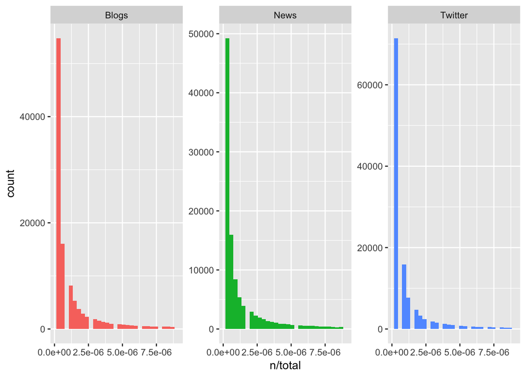

```r
ggplot(corpus_words, aes(n/total, fill = id)) +
        geom_histogram(show.legend = FALSE) +
        xlim(NA, 0.000009) +
        facet_wrap(~id, ncol = 3, scales = "free_y")
```

The plots exhibit similar distributions for the three data sets. There are many words that occur rarely and fewer that occur frequently. Zip’s law states that the frequency that a word appears is inversely proportional to its rank.

```r
All_words <- WordToken %>%
        count(word, sort = TRUE) %>%
        mutate(word = factor(word, levels = rev(unique(word))),
               prop = n/sum(n), #create variable with the proportion of word frequency in the text corpus
               row = row_number(), #create variable with to easily see how many words correspond to the previous calculation
               cumprop = cumsum(prop)) %>% #calculate the cumulative sum of the proportions
        arrange(desc(cumprop)) #order proportions by descent order

All_words
```

```
## # A tibble: 242,495 × 5
##                                                word     n         prop
##                                              <fctr> <int>        <dbl>
## 1  zzzzzzzzzzzzzzzzzzzzzzzzzzzzzzzzzzzzzzzzzzzzzzzz     1 1.214111e-07
## 2                                      zzzzzzzzzzzz     1 1.214111e-07
## 3                                         zzzzzzzzz     1 1.214111e-07
## 4                                           zzzzzzz     1 1.214111e-07
## 5                                            zzzzzz     1 1.214111e-07
## 6                                              zzzt     1 1.214111e-07
## 7                                              zzzs     1 1.214111e-07
## 8                                              zzzd     1 1.214111e-07
## 9                                              zzup     1 1.214111e-07
## 10                                            zzril     1 1.214111e-07
## # ... with 242,485 more rows, and 2 more variables: row <int>,
## #   cumprop <dbl>
```

How many words correspond to 50% of all word instancies/observations?

```r
Below50 <- All_words %>%
        filter(cumprop <= .501) #filter 50% of the observations

Below50
```

```
## # A tibble: 1,643 × 5
##          word     n         prop   row   cumprop
##        <fctr> <int>        <dbl> <int>     <dbl>
## 1     atlanta   959 0.0001164332  1643 0.5009632
## 2    separate   960 0.0001165546  1642 0.5008467
## 3      pepper   960 0.0001165546  1641 0.5007302
## 4    approved   960 0.0001165546  1640 0.5006136
## 5         arm   962 0.0001167974  1639 0.5004971
## 6       smoke   964 0.0001170403  1638 0.5003803
## 7         pic   964 0.0001170403  1637 0.5002632
## 8     phoenix   964 0.0001170403  1636 0.5001462
## 9  confidence   964 0.0001170403  1635 0.5000291
## 10    william   965 0.0001171617  1634 0.4999121
## # ... with 1,633 more rows
```

How many words correspond to 90% of all observations?

```r
Below90 <- All_words %>%
        filter(cumprop <= .901) #filter 90% of the observations
Below90
```

```
## # A tibble: 20,534 × 5
##           word     n         prop   row   cumprop
##         <fctr> <int>        <dbl> <int>     <dbl>
## 1     forestry    36 4.370798e-06 20534 0.9009990
## 2       foreal    36 4.370798e-06 20533 0.9009946
## 3        foley    36 4.370798e-06 20532 0.9009903
## 4    flagstaff    36 4.370798e-06 20531 0.9009859
## 5  fitzpatrick    36 4.370798e-06 20530 0.9009815
## 6    firestone    36 4.370798e-06 20529 0.9009771
## 7     finalize    36 4.370798e-06 20528 0.9009728
## 8       feeder    36 4.370798e-06 20527 0.9009684
## 9   fatalities    36 4.370798e-06 20526 0.9009640
## 10      faried    36 4.370798e-06 20525 0.9009597
## # ... with 20,524 more rows
```

===============================================================================

## 4. How do you evaluate how many of the words come from foreign languages?

I would use an english dictionary or a list of english words and match with each sentence/word in the text corpus. For this the hunspell package could be useful to detect words that would not match with the list. These words would be considered foreign words or typed not accordingly. I would keep those in the text still for future predictions with bi-grams and tri-grams, meaning that when more than one non-english word occurs there can be a chance that the next words predicted are non-english words as well.

===============================================================================

## 5. Can you think of a way to increase the coverage - identifying words that may not be in the corpora or using a smaller number of words in the dictionary to cover the same number of phrases?

- Use `tm` package for stemming, to reduce complexity of words and match with language extensions that come with packages such as `Rstem`.
- Generate term-document matrices
- Import/use a online dictionary and match words with 50% of the corpus word instancies
- Use a Markov chain as a measure to save memory and randomly predict n-grams.

===============================================================================

**Interesting facts:**

- Calculation of word frequencies without the text cleaning, reveals higher frequency of strange characters and words that are a repetition of vowels. For this matter, `cleanAll` represents a version of the data without these original elements.
- Although stopwords are removed at this part of the project as they don’t add value to the calculation of word frequencies (tf_idf). These words should be included in the modelling part as they are connectors in the language, thus needed in an app like swiftkey.
- The distribution of word frequencies is skewed and the result for most common words is in accordance to Zip’s law. For this reason term frequencies are considered along with inverse document frequencies. For more information check document `Word_frequencies_exploratory_analysis`